# Matematikai statisztika 1. gyakorlat, 2025/2026 I. félév

## Elmélet: Leíró statisztikák, statisztikai alapfogalmak, becslések

**Definíció:** (*Minta*). $X_1,...,X_n$ valószínűségi változó sorozat. A továbbiakban feltesszük, hogy függetlenek és azonos eloszlásúak. Realizációja: $x_1,...,x_n$.

**Definíció:** (*Statisztika*). A minta valamely függvénye, pl.:

Mintaátlag v. átlag: $\overline{X}=\frac{1}{n}\sum \limits_{i=1}^n X_i$

Tapasztalati szórás: $S_n=\sqrt{ \frac{1}{n}\sum \limits_{i=1}^n (X_i-\overline{X})^2}$ (az átlagtól való átlagos eltérés)

Korrigált tapasztalati szórás: $S_n^*=\sqrt{\frac{1}{n-1}\sum \limits_{i=1}^n (X_i-\overline{X})^2}$

Szórási együttható (vagy relatív szórás): $V=\frac{S_n}{\overline{X}}=\frac{S_n}{\overline{X}} 100\%$ (az átlagtól való átlagos eltérés százalékban.) Lehet a korrigált tapasztalati szórással is számolni.

k-adik tapasztalati momentum ($k \ge 1, k \in \mathbb{Z}$): $m_k=\frac{1}{n}\sum \limits_{i=1}^n X^k_i$

Tapasztalati módusz: a legtöbbször előforduló érték

Rendezett minta: $X_1^*\leq ... \leq X_n^*$ a mintaelemek nem csökkenő sorrendben

Tapasztalati medián: $X^*_\frac{n+1}{2}$, ha $n$ páratlan és $\frac{X^*_\frac{n}{2}+ X^*_{\frac{n}{2}+1}}{2}$, ha $n$ páros

Terjedelem: $R=X_n^*-X_1^*$ (legnagyobb $-$ legkisebb mintaelem)

$z$-kvantilis: $q_z=\inf \{x: F(x) \geq z \}$. Ha $F$ invertálható, akkor $q_z=F^{-1}(z).$

Tapasztalati $z$-kvantilis: $q_z=\inf \{x: \hat F_n(x)>z \}.$ Értelmezése: a mintaelemek $z$-ed része legfeljebb a $q_z$, ($1-z$)-ed része pedig legalább a $q_z$ értéket veszi fel ($0 < z <1$); sokféleképpen számolható, pl. interpolációs módszerrel: először megállapítjuk a sorszámot: $(n+1)z=e+t$ ($e$: egészrész, $t$: törtrész), majd kiszámoljuk a $z$-kvantilist: $q_z=X_e^*+t(X_{e+1}^*-X_e^*)$.

Kvartilisek: Speciális kvantilisek, alsó (vagy első) kvartilis: $Q_1 = q_{\frac{1}{4}}$, $Q_2=q_{\frac{1}{2}}$, felső (vagy harmadik) kvartilis: $Q_3=q_{\frac{3}{4}}$

Interkvartilis terjedelem: $IQR=q_{\frac{3}{4}} - q_{\frac{1}{4}} = Q_3-Q_1$

Tapasztalati eloszlásfüggvény: $F_n(x)=\frac{1}{n}\sum \limits_{i=1}^n I(X_i<x)$, ahol $I(X_i<x)= \begin{cases} 1 & \text{ ha }X_i<x \\ 0 & \text{ ha }X_i \geq x \end{cases}$ indikátor függvény

**Tétel:** (*Glivenko-Cantelli*). Az $F_n(x)$ tapasztalati eloszlásfüggvény és az $F(x)$ elméleti eloszlásfüggvény közötti eltérés maximuma $1$ valószínűséggel 0-hoz konvergál, ami azt jelenti, hogy elég nagy minta esetén $F_n(x)$ értéke minden $x$-re tetszőleges közel van $F(x)$ értékéhez és $n$-et növelve mindenütt annak közelében marad.

**Definíció:** (*Boxplot*).

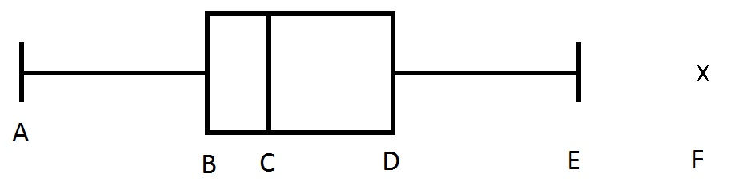

$A=\max\{ x_1^*,Q_1-1,5 \cdot IQR \}$; $B=Q_1$; $C=Q_2$; $D=Q_3$; $E=\min\{ x_n^*,Q_3+1,5 \cdot IQR \}$; $F$: kieső értékek, azokat tüntetjük fel pontokként, amik $A$-n vagy $E$-n kívülre esnek.

## R telepítés

A nyelv telepítéséhez szükséges instrukciók és fájlok [itt](https://cran.r-project.org/) érhetőek el. Az RStudio pedig [itt](https://posit.co/download/rstudio-desktop/).

## Feladatok

**1. Feladat** Háromszor feldobtunk egy kockát és a következőket kaptuk: 5, 3, 6.

1. Határozzuk meg a következő középértékeket: átlag, medián!
2. Adjuk meg a rendezett mintát!
3. Határozzuk meg minden valós $x$-re annak a relatív gyakoriságát, hogy a kísérletünk során $x$-nél kisebb értéket kaptunk. Ábrázoljuk a kapott függvényt!

**2. Feladat** Egy szabályos dobókockával nyolcszor dobtunk és a következőket kaptuk: 2, 4, 3, 5, 6, 5, 1, 3. Számítsuk ki és rajzoljul fel a tapasztalati eloszlásfüggvényt! Mi a kockadobás elméleti eloszlásfüggvénye?

*Extra feladat:* Az R program segítségével a `runif` utasítás megfelelő paraméterezésével és módosításával generáljunk 100 kockadobást és ábrázoljunk annak tapasztalati eloszlásfüggvényét!

**3. Feladat** Egy osztályban a diákok magassága: 180, 163, 150, 157, 165, 165, 174, 191, 172, 165, 168, 186 cm. Elemezzük a diákok testmagasságát az átlag, a korrigált tapasztalati szórás, szórási együttható és boxplot ábra (kvartilisek) segítségével! Értelmezzük az eredményeket!

**4. Feladat** Rajzoljuk fel az előző feladatban a diákok magasságára vonatkozó tapasztalati eloszlásfüggvényt!

**5. Feladat** Igaz-e, hogy ha egy minta esetén $Q_1=Q_3=9$, akkor a medián = $9$?

**6. Feladat** Egy állatkísérletben $30$ egér tömegét mérték. A következő értékeket kapták: $q_{0,3}=17,6$ gramm és $F_{30}(19)=0,9$. Értelmezzük szövegesen ezek jelentését!

**7. Feladat** Két csoport diákjai magasságát (cm) tartalmazza az alábbi táblázat:

| **I. csoport (cm)** | 131 | 150 | 147 | 138 | 144 |
| --- | --- | --- | --- | --- | --- |
| **II. csoport (cm)** | 139 | 148 | 132 | 151 | 140 |

1. Melyek igazak az alábbiak közül?
   1. A minták terjedelme a két csoportban ugyanakkora.
   2. A mintaátlagok megegyeznek.
   3. Az interkvartilis terjedelmek ugyanakkorák.
2. Az I. csoport adatainak mintaátlaga $142$ cm, szórása $7,58$ cm. Számoljuk ki a szórási együtthatót! Mit jelent a mintaátlag, szórás és szórási együttható a szövegkörnyezetben?

**8. feladat** Vizsgáljuk meg a Nyíregyházán és Karcagon mért 1951 és 1988 közti napi középhőmérsékleti adatokat, melyek a következő helyeken érhetőek el: [Nyíregyháza](http://zempleni.elte.hu/nyir-51-88m.hom), [Karcag](http://zempleni.elte.hu/karc-51-88.hom). Ha találunk hibásnak tűnő adatpontot, adjunk javaslatot annak kijavítására.

## Szorgalmi feladatok

**1. feladat** *(2 pont)* Legyen az alábbi egy 20 elemű minta gyakorisági táblája, ahol $-1\leq x\leq 2$ ismeretlen:

| Érték | -1 | x | 2 |
| --- | --- | --- | --- |
| Gyakoriság | 4 | 10 | 6 |

Számoljuk ki a megfigyeléseink átlagát, mediánját, korrigált tapasztalati szórását és szórási együtthatóját! $x$ mely értékei esetén lesznek ezek minimálisak, maximálisak?